# Ejemplos de uso de Phytools

Lo primero es tener cargado el paquete de phytools

```r
library(phytools)
```

## Ejemplo 1: Poner barras de error a una filogenia

Tomado de [esta entrada del blog de phylotools](http://blog.phytools.org/2017/03/error-bars-on-divergence-times-on.html)

Primero simular un árbol e intervalos de confianza cada nodo:

```r
tree<-pbtree(n=26,tip.label=LETTERS[26:1],scale=100)
h<-sapply(1:tree$Nnode+Ntip(tree),nodeheight,tree=tree)
CI<-cbind(h-runif(n=length(h),min=10,max=20),h+runif(n=length(h),
    min=5,max=10))
CI[CI>max(nodeHeights(tree))]<-max(nodeHeights(tree))
CI<-max(nodeHeights(tree))-CI
rownames(CI)<-1:tree$Nnode+Ntip(tree)
colnames(CI)<-paste(c("lower","upper"),"(MYBP)")

tree
```

```
##
## Phylogenetic tree with 26 tips and 25 internal nodes.
##
## Tip labels:
##  Z, Y, X, W, V, U, ...
##
## Rooted; includes branch lengths.
```

```r
CI # confidence intervals
```

```
##    lower (MYBP) upper (MYBP)
## 27    119.90922   94.4881980
## 28     69.61258   46.1962862
## 29     69.97746   43.9636243
## 30     52.82333   27.2312128
## 31     30.48953    6.6948137
## 32     19.59445    0.7459348
## 33     63.41105   41.4878539
## 34     45.69594   26.9729256
## 35     42.03523   19.2848529
## 36     22.23824    0.0000000
## 37     40.46447   14.0955687
## 38     29.52821    8.5818558
## 39     25.95406    2.6290242
## 40     34.65845   13.1245080
## 41     16.46182    0.0000000
## 42     52.85881   28.0835702
## 43     34.24380    7.9036451
## 44     87.01962   66.8946049
## 45     75.26518   49.4674704
## 46     54.30194   33.2233062
## 47     35.49134   11.8514634
## 48     47.75291   20.9564992
## 49     20.22447    0.0000000
## 50     20.29607    0.3114736
## 51     58.48431   37.4769020
```

Y ahora el plot

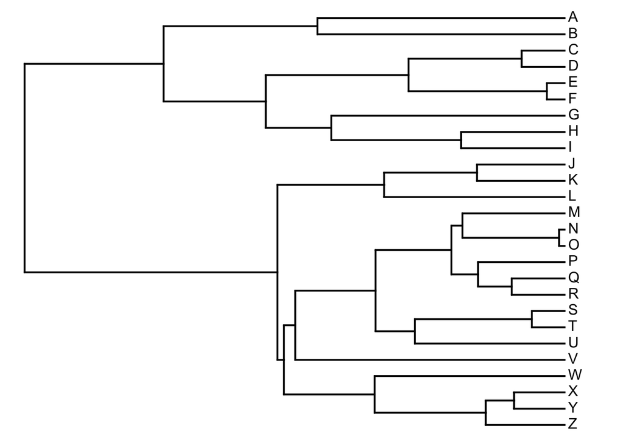

```r
# básico
plotTree(tree)
```

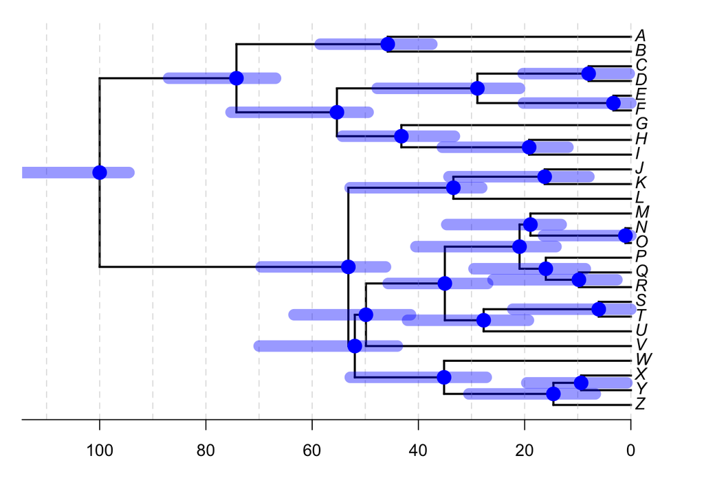

```r
# apachurrarlo un poquito para que entre un eje con "tiempo"
plotTree(tree,xlim=c(110,-5),direction="leftwards",
    mar=c(4.1,1.1,1.1,1.1),ftype="i")
# lineas verticales para ver el tiempo mejor
abline(v=seq(0,120,by=10),lty="dashed",
    col=make.transparent("grey",0.5))
# eje con tiempo
axis(1,at=seq(0,120,by=20))

# guardar el plot en un objetio
obj<-get("last_plot.phylo",envir=.PlotPhyloEnv)

# utilizar un loop para poner el intervalo de confianza en cada nodo
for(i in 1:tree$Nnode+Ntip(tree))
    lines(x=c(CI[i-Ntip(tree),1],CI[i-Ntip(tree),2]),
        y=rep(obj$yy[i],2),lwd=11,lend=0,
        col=make.transparent("blue",0.4))
points(obj$xx[1:tree$Nnode+Ntip(tree)],
    obj$yy[1:tree$Nnode+Ntip(tree)],pch=19,col="blue",
    cex=1.8)
```

Preguntas:

- ¿Por qué contamos los nodos con `1:tree$Nnode+Ntip(tree)`?
- ¿Cómo sabe R qué nodo es cuál y cómo los relaciona con la el objeto `CI`?

## Ejemplo 2: Poner color o puntos en ramas terminales de un árbol

Tomado de [esta entrada del blog de phylotools](http://blog.phytools.org/2017/01/plotting-terminal-edges-of-tree.html)

Simulemos un árbol, parecidísimo al anterior pero con información de estados de un caracter dado para cada rama terminal.

```r
tree<-pbtree(n=26,tip.label=LETTERS)
tree
```

```
##
## Phylogenetic tree with 26 tips and 25 internal nodes.
##
## Tip labels:
##  A, B, C, D, E, F, ...
##
## Rooted; includes branch lengths.
```

```r
# crear edos
Q<-matrix(c(-2,1,1,1,-2,1,1,1,-2),3,3)
Q
```

```
##      [,1] [,2] [,3]
## [1,]   -2    1    1
## [2,]    1   -2    1
## [3,]    1    1   -2
```

```r
rownames(Q)<-colnames(Q)<-letters[1:3]
Q
```

```
##    a  b  c
## a -2  1  1
## b  1 -2  1
## c  1  1 -2
```

```r
x<-as.factor(sim.history(tree,Q)$states)
```

```
## Done simulation(s).
```

```r
x
```

```
## A B C D E F G H I J K L M N O P Q R S T U V W X Y Z
## c a b b a a c b c a a c b c b c a a b c c c a b b a
## Levels: a b c
```

La `x` anterior la creamos para este ejemplo, pero puede ser cualquier info sobre cada una de nuestros tips del árbol.

Ahora utilizar `paintBranches` para colorear las ramas de rojo/azul dependiendo de si la punta está en edo `b` o `c` y dejemos a `a` en negro:

```r
## identify the tips in states b or c
b<-names(x)[x=="b"]
b
```

```
## [1] "C" "D" "H" "M" "O" "S" "X" "Y"
```

```r
c<-names(x)[x=="c"]
c
```

```
## [1] "A" "G" "I" "L" "N" "P" "T" "U" "V"
```

```r
## paint the edges
tt<-paintBranches(tree,edge=sapply(b,match,tree$tip.label),
    state="b",anc.state="a")
tt<-paintBranches(tt,edge=sapply(c,match,tree$tip.label),
    state="c")

tt
```

```
##
## Phylogenetic tree with 26 tips and 25 internal nodes.
##
## Tip labels:
##  A, B, C, D, E, F, ...
##
## The tree includes a mapped, 3-state discrete character with states:
##  a, b, c
##
## Rooted; includes branch lengths.
```

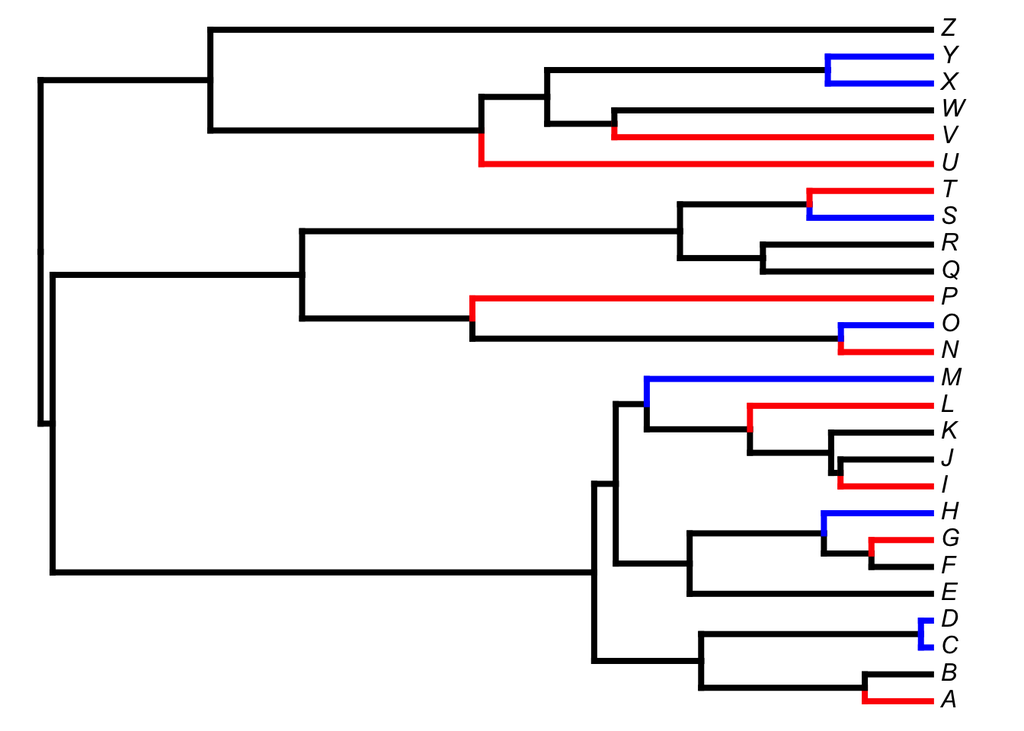

```r
# Plot
cols<-setNames(c("black","blue","red"),c("a","b","c"))
plot(tt,colors=cols,lwd=4,split.vertical=TRUE,ftype="i")
```

Alternativamente, podemos utilizar la función `dotTree` para poner bolitas de colores después de las ramas.

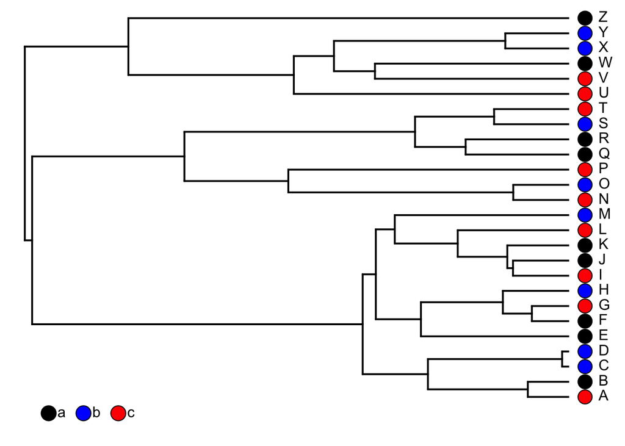

```r
cols<-setNames(c("black","blue","red"),c("a","b","c"))
dotTree(tree,x,colors=cols)
```

**Ejercicio** Combina el árbol de los dos ejemplos anteriores para generar un árbol con intervalos de confienza por nodo y los estados `b`y `c` coloreados de verde y rosa y el `a` de negro. Incluye todo el código para simular el árbol y demás datos que sean necesarios. El resultado final debe verse parecido a la imagen de abajo. Nota que los puntos de los CI cambiaron de tamaño y color con respecto al ejemplo anterior.

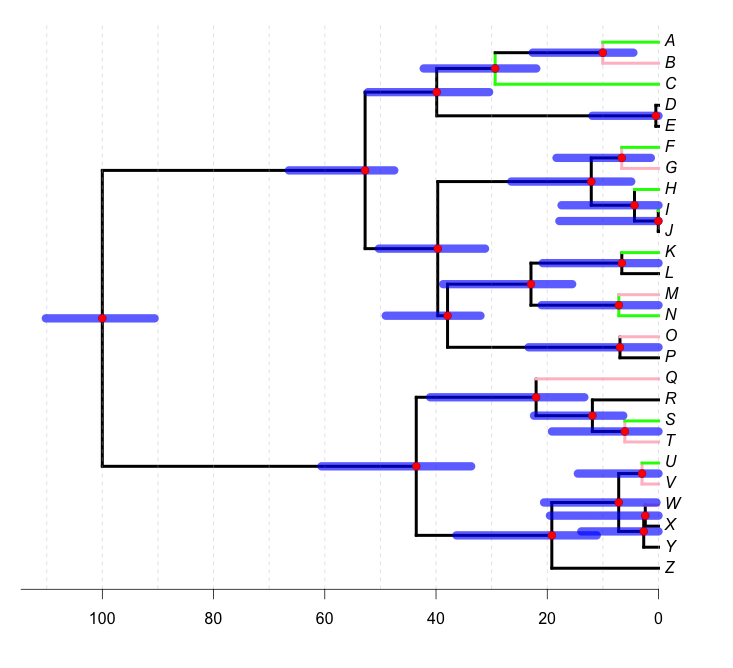